# Tagging Effort Analysis

Myfanwy Johnston

July 27, 2016

# Power Analysis - or, why we’re not doing one

The reason to do a power analysis is to determine whether your sample size will give you a decent chance of detecting an “effect” in an experiment - that is, a decent chance of detecting some minimum deviation from the null hypothesis and the alternative hypothesis. In our case, for example, we’d like to tag enough fish so that a good number of them continue upstream after being tagged. With a normal experimental design, if we assume the true proportion of fish that head upstream is what we’ve observed in the past (between 10-35%), we could do an exact binomial test and get the sample size we need to make sure we detect 50% or more (an arbitrary number) of our fish heading upstream. According to a quick exact binomial goodness-of-fit power analysis, this would give us a target sample size of between 77 and 140; not helpful.

A traditional power analysis doesn’t *really* apply in our case anyway, because we do actually detect the “effect” in question at almost 100% efficiency; we know whether every single one of our fish goes either upstream or downstream. So it’s not a matter of detecting the true proportion of fish that go in a given direction, it’s predicting our fishes’ *behavior*, conditional on tagging location and tag date. And the best tool we have available for doing that is the past behavior of our fish.

# Does it matter when and where we tag fish?

In the last YETT meeting, I mentioned that tagging location doesn’t seem to have as large an effect on whether a fish heads upstream as we previously thought. After looking deeper, that’s still true if we just examine the direction a fish heads in right after being tagged: most fish head upstream, regardless of tagging location. That said, if we limit the analysis to the fish that are eventually detected above Lisbon Weir, the story is quite different.

In general, fish tagged later in the season and higher up in the system have a much better chance of being subsequently detected upstream of Lisbon Weir.

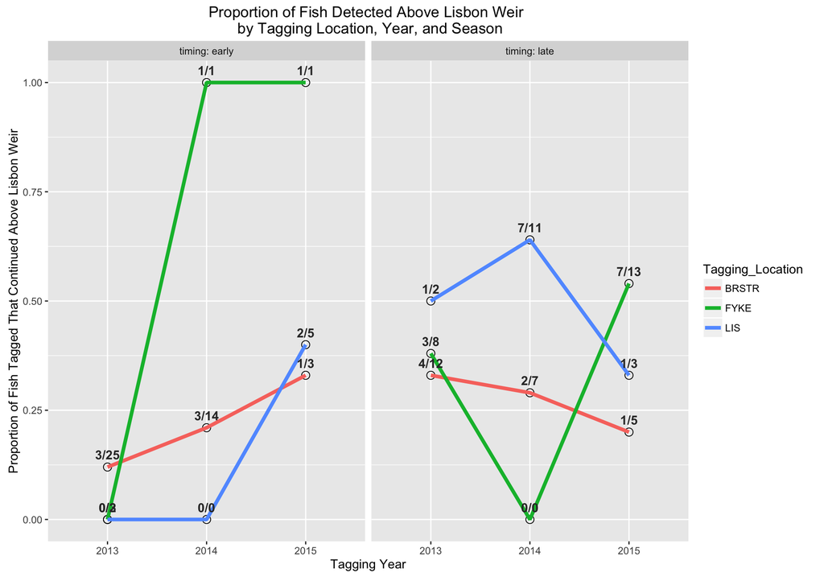

# Clearing out the noise to find a prior

When we calculate weighted averages and raw averages, we get a range of probabilities for fish ending up above Lisbon Weir, depending on whether you sample them early or late, and upstream or downstream:

| Timing | General Tagging Location | Percentage Range of Fish Sampled that will Continue Upstream |
| --- | --- | --- |
| Early | Downstream | 17% - 22% |
| Early | Upstream | 13% - 80% |
| Late | Downstream | 27% - 29% |
| Late | Upstream | 46% - 57% |

To remain consistent with past years, we have a lot of flexibility, but in general we’ve always had a slightly smaller sample size early in the season relative to late, and I’m happy to push that a little further to increase our odds of getting fish going upstream. This means we can tag about 17 fish before October 20 (early) and 33 fish after October 20 (late). Totals for each sampling location will be:

- BRSTR: between 13-36 fish
- FYKE: between 1 and 23 fish (obviously we have no control over this)
- LIS: between 4 and 16 fish.

As for how we should break that up in the tagging season, I ran a lot of different combinations through a paired binomial sampling distrubutions simulation. I’m showing the code for the functions I set up, with the final numbers I chose, so people can try it for themselves or pick it apart and find any mistakes:

```r
# total N early: 18 between upstream and downstream
# total N late: 32 between upstream and downstream

set.seed(1)
simPessimistic <- function(UpstreamEarly, UpstreamLate) {
  # UpstreamEarly = sample size of fish tagged at either LIS or in the FYKE, before October 20
  # UpstreamLate = sample size of fish tagged at either LIS or in the FYKE, after October 20.

  early <- rbinom(1000, size = UpstreamEarly, prob = 0.13) + rbinom(1000, size = 17-UpstreamEarly, prob = 0.17)
    # 1000 is the number of random binomial distributions simulated
    # size = UpstreamEarly
    # prob = lower range of the probability of being detected abvlis if tagged early upstream, based on previous       years' data
    # second prob = lower range of the probability of being detected abvlis if tagged early downstream, based on previous years' data

  late <- rbinom(1000, size = UpstreamLate, prob = 0.46) +  rbinom(1000, size = 33-UpstreamLate, prob = 0.27)
    # size = UpstreamLate
    # prob = lower range of the probability of of being detected abvlis if tagged late upstream
    # second prob = lower range of the probability of being detected abvlis if tagged late downstream
  ss <- early + late
  frac = sum(ss > 18)/length(ss) # where 18 is the minimum number of fish we want detected above LIS.
  return(frac) # this is the fraction of the results of the simulations that = 18 or greater.
}
simPessimistic(UpstreamEarly = 7, UpstreamLate = 28)
```

```
## [1] 0.291
```

```r
simOptimistic <- function(UpstreamEarly, UpstreamLate) {
  # This is the exact same function as above, but with the probabilities changed to the upper limits of the range

   early <- rbinom(1000, size = UpstreamEarly, prob = 0.80) + rbinom(1000, size = 17-UpstreamEarly, prob = 0.22)

   late <- rbinom(1000, size = UpstreamLate, prob = 0.57) + rbinom(1000, size = 33-UpstreamLate, prob = 0.29)

  ss <- early + late
  frac = sum(ss > 18)/length(ss)
  return(frac)
}

simOptimistic(UpstreamEarly = 7, UpstreamLate = 28)
```

```
## [1] 0.985
```

# What the simulations say

# Summary

I know that’s waaaay too much information and I could have just told you the tagging plan, but I’d love it if someone could point out anywhere I’m using bad logic. Let me know if you have any questions!